# Tomato_SimpleTidy_vs_WGCNA

Chenxin Li

2023-01-13

# Introduction

This work sheet aims to compare Li’s SimpleTidy GeneCoEx workflow with the WGCNA package. [WGCNA](https://bmcbioinformatics.biomedcentral.com/articles/10.1186/1471-2105-9-559) is regarded as the “method of choice” by some for gene co-expression analyses. We will be benchmarking the two workflows using the tomato fruit developmental series data. Ref: [Shinozaki et al., 2018](https://www.nature.com/articles/s41467-017-02782-9).

# Dependencies

```r
library(tidyverse)
library(WGCNA)
library(ggalluvial)
library(ggbeeswarm)

library(patchwork)
library(RColorBrewer)
library(viridis)

set.seed(666)
```

I kind of ran into a dependency hell for WGCNA. I sorted it out using these steps:

1. Install BioConductor Manager: `install.packages("BiocManager")`
2. Install WGCNA from BioConductor: `BiocManager::install("WGCNA", force = T)`

Hopefully you don’t run into this issue. If you do, hopefully my fix works for you.

# Load data

I already performed gene co-expression and clustering analyses using my “Simply Tidy Gene CoEx” workflow. I will just import the results from my analyses first.

## Simple Tidy results

```r
modules_mean_z_reorded <- read_csv("../Results/modules_mean_z_reordered.csv", col_types = cols())
my_network_modules <- read_csv("../Results/my_network_modules.csv", col_types = cols())
Exp_table_long_averaged_z_high_var_modules <- read_csv("../Results/Exp_table_long_averaged_z_high_var_modules.csv", col_types = cols())
```

I am reading in 3 tables.

1. `modules_mean_z_reordered` contains the mean z score of all genes in each module across developmental stages and tissues.
2. `my_network_modules` contains the module membership for each gene in the analyses.
3. `Exp_table_long_averaged_z_high_var_modules` contains the z score of genes in each module.

For WGCNA, I need a normalized gene expression matrix. Let’s make that from the tpm table.

```r
Exp_table <- read_csv("../Data/Shinozaki_tpm_representative_transcripts.csv", col_types = cols())
head(Exp_table)
```

| ...1 | SRR5724446 | SRR5724445 | SRR5724444 | SRR5724443 | SRR5724044 | SRR5724442 | SRR5724441 | SRR5724440 | SRR5724003 | SRR5724002 | SRR5724438 | SRR5724437 | SRR5724001 | SRR5724000 | SRR5723999 | SRR5723998 | SRR5724005 | SRR5724004 | SRR5723997 | SRR5723996 | SRR5724093 | SRR5724092 | SRR5724091 | SRR5724090 | SRR5724089 | SRR5724088 | SRR5724087 | SRR5724086 | SRR5724226 | … |
| --- | --- | --- | --- | --- | --- | --- | --- | --- | --- | --- | --- | --- | --- | --- | --- | --- | --- | --- | --- | --- | --- | --- | --- | --- | --- | --- | --- | --- | --- | --- |
| Solly.M82.08G017810.4 | 66.76540 | 66.98420 | 88.01810 | 95.361300 | 92.10410 | 105.36700 | 123.26800 | 123.0510 | 148.74500 | 147.266000 | 162.32500 | 134.52800 | 102.42800 | 104.06300 | 91.20640 | 102.25500 | 171.4870 | 148.28400 | 156.57700 | 162.24900 | 151.5700 | 150.44000 | 128.17900 | 149.8140 | 128.38400 | 101.24800 | 97.2453 | 107.27900 | 150.3780 | … |
| Solly.M82.09G025810.1 | 18.33240 | 24.73540 | 26.02410 | 22.148500 | 24.17910 | 30.95910 | 29.73150 | 24.7602 | 16.26310 | 17.944500 | 18.28220 | 18.33720 | 28.29060 | 27.79240 | 24.17670 | 24.54840 | 29.0998 | 26.66360 | 26.83520 | 23.45840 | 28.2633 | 26.53490 | 30.30530 | 28.1207 | 28.12310 | 24.98020 | 30.1740 | 28.84930 | 16.8770 | … |
| Solly.M82.02G008100.1 | 0.00000 | 0.00000 | 0.00000 | 0.466124 | 0.00000 | 0.00000 | 0.00000 | 0.0000 | 0.00000 | 0.292796 | 0.00000 | 0.00000 | 0.00000 | 0.00000 | 0.00000 | 0.00000 | 0.0000 | 0.00000 | 0.00000 | 0.00000 | 0.0000 | 0.00000 | 0.00000 | 0.0000 | 0.00000 | 0.00000 | 0.0000 | 0.00000 | 0.0000 | … |
| Solly.M82.03G002810.1 | 11.56680 | 5.78868 | 11.00500 | 9.308770 | 10.73910 | 8.16611 | 6.48864 | 10.9089 | 2.74528 | 5.847310 | 6.32798 | 6.48419 | 4.82302 | 3.76552 | 7.32202 | 6.92918 | 10.8443 | 7.82213 | 4.79728 | 2.12634 | 4.1935 | 9.10771 | 4.48356 | 12.1869 | 3.81034 | 2.05449 | 0.0000 | 8.40111 | 14.0715 | … |
| Solly.M82.10G021790.2 | 180.15400 | 174.73100 | 198.17200 | 178.698000 | 169.63500 | 158.47300 | 157.69300 | 158.7160 | 100.27000 | 102.595000 | 105.19200 | 94.64470 | 75.04060 | 67.64930 | 79.70450 | 74.61380 | 76.5897 | 69.16960 | 68.06220 | 65.09580 | 71.5828 | 71.36250 | 67.50060 | 81.1656 | 74.42540 | 65.54090 | 66.3913 | 73.91320 | 80.9200 | … |
| Solly.M82.08G013300.1 | 8.01774 | 8.82759 | 7.62835 | 9.356210 | 9.49665 | 10.35820 | 10.14670 | 10.8025 | 8.65842 | 8.815680 | 10.42260 | 8.53983 | 10.69820 | 10.17960 | 10.53150 | 13.83290 | 11.4585 | 13.82630 | 15.04710 | 13.11790 | 13.8073 | 12.13540 | 11.49910 | 11.6577 | 14.65870 | 13.81390 | 11.2013 | 13.27740 | 10.8513 | … |

For the rest of this workflow, I will be following this [tutorial for WCGNA](https://bioinformaticsworkbook.org/tutorials/wgcna.html#gsc.tab=0).

# Gene selection for WGCNA

While it is not covered in the tutorial for WGCNA, Shinozaki et al. performed gene selection steps based on coefficient of variation (CV). CV is the ratio of sd over mean.

> Co-expression network modules were identified using averaged RPM values and the WGCNA package (v1.51) in. Genes with a low coefficient of variation of averaged RPM (CV < 1) among all sample types (cell/tissue types, different latitudinal sections, or developmental stages) were discarded and the remaining 12,662 genes were used for the analysis.

We will do things slightly different here. Since we have TPM table, we will use averaged TPM values instead of RPM. Secondly, for the purpose of benchmarking, I will only use samples that are hand dissected (without using laser micro-dissection samples). Thirdly, again for the purpose of benchmarking, I will only the top 5000 variable genes.

Let’s pull those top variable genes.  
## Wide to long

```r
Exp_table_long <- Exp_table %>%
  rename(gene_ID = `...1`) %>%
  pivot_longer(cols = !gene_ID, names_to = "library", values_to = "tpm") %>%
  mutate(logTPM = log10(tpm + 1))

head(Exp_table_long)
```

| gene_ID | library | tpm | logTPM |
| --- | --- | --- | --- |
| Solly.M82.08G017810.4 | SRR5724446 | 66.7654 | 1.831008 |
| Solly.M82.08G017810.4 | SRR5724445 | 66.9842 | 1.832408 |
| Solly.M82.08G017810.4 | SRR5724444 | 88.0181 | 1.949478 |
| Solly.M82.08G017810.4 | SRR5724443 | 95.3613 | 1.983903 |
| Solly.M82.08G017810.4 | SRR5724044 | 92.1041 | 1.968969 |
| Solly.M82.08G017810.4 | SRR5724442 | 105.3670 | 2.026807 |

## Average up reps

To average up reps, we need the metadata. Let’s load that.

| Run | AvgSpotLen | Bases | BioProject | BioSample | Experiment | Instrument | LibraryLayout | LibrarySelection | LibrarySource | Platform | Sample Name | SRA Study | Cultivar | tissue | Library Name | dev_stage |
| --- | --- | --- | --- | --- | --- | --- | --- | --- | --- | --- | --- | --- | --- | --- | --- | --- |
| SRR5724446 | 101 | 533436348 | PRJNA391024 | SAMN07256505 | SRX2940334 | Illumina HiSeq 2500 | SINGLE | RANDOM | TRANSCRIPTOMIC | ILLUMINA | J4 | SRP109982 | M82 | Total pericarp | J4-2 | 5 DPA |
| SRR5724445 | 101 | 624313017 | PRJNA391024 | SAMN07256505 | SRX2940335 | Illumina HiSeq 2500 | SINGLE | RANDOM | TRANSCRIPTOMIC | ILLUMINA | J4 | SRP109982 | M82 | Total pericarp | J4-1 | 5 DPA |
| SRR5724444 | 101 | 872354574 | PRJNA391024 | SAMN07256505 | SRX2940336 | Illumina HiSeq 2500 | SINGLE | RANDOM | TRANSCRIPTOMIC | ILLUMINA | J4 | SRP109982 | M82 | Total pericarp | J4-4 | 5 DPA |
| SRR5724443 | 101 | 456573631 | PRJNA391024 | SAMN07256505 | SRX2940337 | Illumina HiSeq 2500 | SINGLE | RANDOM | TRANSCRIPTOMIC | ILLUMINA | J4 | SRP109982 | M82 | Total pericarp | J4-3 | 5 DPA |
| SRR5724044 | 101 | 779407304 | PRJNA391024 | SAMN07256506 | SRX2940253 | Illumina HiSeq 2500 | SINGLE | RANDOM | TRANSCRIPTOMIC | ILLUMINA | J8 | SRP109982 | M82 | Total pericarp | J8-3 | 10 DPA |
| SRR5724442 | 101 | 678634756 | PRJNA391024 | SAMN07256506 | SRX2940338 | Illumina HiSeq 2500 | SINGLE | RANDOM | TRANSCRIPTOMIC | ILLUMINA | J8 | SRP109982 | M82 | Total pericarp | J8-2 | 10 DPA |

```r
Exp_table_long_averaged <- Exp_table_long %>%
  full_join(Metadata %>%
              select(Run, `Sample Name`, tissue, dev_stage),
            by = c("library"="Run")) %>%
   mutate(dissection_method = case_when(
    str_detect(tissue, "epidermis") ~ "LM",
    str_detect(tissue, "Collenchyma") ~ "LM",
    str_detect(tissue, "Parenchyma") ~ "LM",
    str_detect(tissue, "Vascular") ~ "LM",
    str_detect(dev_stage, "Anthesis") ~ "LM",
    str_detect(dev_stage, "5 DPA") &
      str_detect(tissue, "Locular tissue|Placenta|Seeds") ~ "LM",
    T ~ "Hand"
  )) %>%
  filter(dissection_method == "Hand") %>%
  group_by(gene_ID, `Sample Name`, tissue, dev_stage) %>%
  summarise(mean.logTPM = mean(logTPM)) %>%
  ungroup()
head(Exp_table_long_averaged)
```

| gene_ID | Sample Name | tissue | dev_stage | mean.logTPM |
| --- | --- | --- | --- | --- |
| Solly.M82.00G000010.1 | J10 | Placenta | 10 DPA | 0.00000000 |
| Solly.M82.00G000010.1 | J11 | Locular tissue | 10 DPA | 0.00000000 |
| Solly.M82.00G000010.1 | J12 | Seeds | 10 DPA | 0.00000000 |
| Solly.M82.00G000010.1 | J14 | Columella | 20 DPA | 0.00000000 |
| Solly.M82.00G000010.1 | J15 | Total pericarp | 20 DPA | 0.00000000 |
| Solly.M82.00G000010.1 | J16 | Septum | 20 DPA | 0.05524167 |

As in the Simple Tidy workflow, we only took hand dissected samples. This step could take a while.

## z score

```r
Exp_table_long_averaged_z <- Exp_table_long_averaged %>%
  group_by(gene_ID) %>%
  mutate(z.score = (mean.logTPM - mean(mean.logTPM))/sd(mean.logTPM)) %>%
  ungroup()

head(Exp_table_long_averaged_z)
```

| gene_ID | Sample Name | tissue | dev_stage | mean.logTPM | z.score |
| --- | --- | --- | --- | --- | --- |
| Solly.M82.00G000010.1 | J10 | Placenta | 10 DPA | 0.00000000 | -0.3617844 |
| Solly.M82.00G000010.1 | J11 | Locular tissue | 10 DPA | 0.00000000 | -0.3617844 |
| Solly.M82.00G000010.1 | J12 | Seeds | 10 DPA | 0.00000000 | -0.3617844 |
| Solly.M82.00G000010.1 | J14 | Columella | 20 DPA | 0.00000000 | -0.3617844 |
| Solly.M82.00G000010.1 | J15 | Total pericarp | 20 DPA | 0.00000000 | -0.3617844 |
| Solly.M82.00G000010.1 | J16 | Septum | 20 DPA | 0.05524167 | 2.9076340 |

## Find top 5000 variable

```r
high_var_genes <- Exp_table_long_averaged_z %>%
  group_by(gene_ID) %>%
  summarise(var = var(mean.logTPM)) %>%
  ungroup() %>%
  filter(var > quantile(var, 0.667))

high_var_genes5000 <- high_var_genes %>%
  slice_max(order_by = var, n = 5000)

head(high_var_genes5000)
```

| gene_ID | var |
| --- | --- |
| Solly.M82.08G013600.3 | 2.589940 |
| Solly.M82.08G022780.1 | 2.083183 |
| Solly.M82.06G008610.1 | 1.963280 |
| Solly.M82.09G018780.1 | 1.927932 |
| Solly.M82.01G023870.1 | 1.906894 |
| Solly.M82.07G027030.1 | 1.894391 |

```r
dim(high_var_genes5000)
```

```
[1] 5000    2
```

```r
Exp_table_long_averaged_z_high_var <- Exp_table_long_averaged_z %>%
  filter(gene_ID %in% high_var_genes5000$gene_ID)

head(Exp_table_long_averaged_z_high_var)
```

| gene_ID | Sample Name | tissue | dev_stage | mean.logTPM | z.score |
| --- | --- | --- | --- | --- | --- |
| Solly.M82.00G000190.3 | J10 | Placenta | 10 DPA | 1.1025570 | 1.2029826 |
| Solly.M82.00G000190.3 | J11 | Locular tissue | 10 DPA | 1.2318901 | 1.5012085 |
| Solly.M82.00G000190.3 | J12 | Seeds | 10 DPA | 1.7997030 | 2.8105125 |
| Solly.M82.00G000190.3 | J14 | Columella | 20 DPA | 0.9828509 | 0.9269558 |
| Solly.M82.00G000190.3 | J15 | Total pericarp | 20 DPA | 0.9965383 | 0.9585171 |
| Solly.M82.00G000190.3 | J16 | Septum | 20 DPA | 0.8554167 | 0.6331088 |

```r
Exp_table_long_averaged_z_high_var %>%
  group_by(gene_ID) %>%
  count() %>%
  nrow()
```

```
[1] 5000
```

# Input requirement for WGCNA

WGCNA requires matrix with genes are columns and sample as names. Let’s make that.

|  | treatment | Solly.M82.00G000190.3 | Solly.M82.00G000220.1 | Solly.M82.00G000230.1 | Solly.M82.00G000270.1 | Solly.M82.00G000460.1 | Solly.M82.00G000500.1 | Solly.M82.00G000590.1 | Solly.M82.00G001200.1 | Solly.M82.00G001420.1 | Solly.M82.01G000020.2 | Solly.M82.01G000030.3 | Solly.M82.01G000080.1 | Solly.M82.01G000100.9 | Solly.M82.01G000160.1 | Solly.M82.01G000210.1 | Solly.M82.01G000230.1 | Solly.M82.01G000280.1 | Solly.M82.01G000390.1 | Solly.M82.01G000400.2 | Solly.M82.01G000410.1 | Solly.M82.01G000440.1 | Solly.M82.01G000460.1 | Solly.M82.01G000470.1 | Solly.M82.01G000580.1 | Solly.M82.01G000590.1 | Solly.M82.01G000680.1 | Solly.M82.01G000800.1 | Solly.M82.01G000970.2 | … |
| --- | --- | --- | --- | --- | --- | --- | --- | --- | --- | --- | --- | --- | --- | --- | --- | --- | --- | --- | --- | --- | --- | --- | --- | --- | --- | --- | --- | --- | --- | --- |
| Placenta.10 DPA | Placenta.10 DPA | 1.1025570 | 1.660343 | 0.3442552 | 2.050720 | 1.389792 | 1.51783651 | 0.6893761 | 0.00000000 | 0.9866135 | 2.559449 | 1.1637905 | 1.1629868 | 0.5788113 | 0.02456001 | 0.7352784 | 0.5970778 | 0.1121500 | 0.13625635 | 0.8218226 | 0.5459926 | 2.523305 | 1.344889 | 0.03717731 | 1.826550 | 1.814237 | 0.13227890 | 1.723356 | 1.144373 | … |
| Locular tissue.10 DPA | Locular tissue.10 DPA | 1.2318901 | 1.249911 | 0.1159203 | 1.433651 | 1.647452 | 0.60247859 | 0.9400036 | 0.00000000 | 0.4005163 | 2.606844 | 1.1036413 | 0.6559158 | 0.3151990 | 0.00000000 | 0.7050374 | 0.6818236 | 0.1549665 | 0.22488976 | 0.8739933 | 0.2082825 | 2.440344 | 1.113836 | 0.29218237 | 1.725856 | 1.421397 | 0.38045264 | 1.625873 | 0.627043 | … |
| Seeds.10 DPA | Seeds.10 DPA | 1.7997030 | 1.551351 | 0.5111338 | 1.659266 | 1.853729 | 0.37492676 | 1.3052271 | 0.00000000 | 0.1279107 | 2.228607 | 1.4796973 | 0.9987103 | 0.4732348 | 0.00000000 | 0.0000000 | 0.6221475 | 0.2162677 | 0.93468713 | 1.7603222 | 0.2542135 | 2.468446 | 1.201493 | 0.26466450 | 2.076381 | 1.927479 | 0.53435430 | 1.313177 | 1.198899 | … |
| Columella.20 DPA | Columella.20 DPA | 0.9828509 | 1.788455 | 0.7092258 | 2.274016 | 1.146930 | 2.00982991 | 0.6171037 | 0.16832638 | 2.3218576 | 2.556765 | 1.2326302 | 1.2061002 | 0.7444120 | 0.04186942 | 1.0354347 | 0.7624356 | 0.0641377 | 0.19689783 | 0.6777284 | 1.2013433 | 2.448425 | 1.352722 | 0.34123741 | 1.892011 | 2.039767 | 0.02929370 | 1.471414 | 1.512754 | … |
| Total pericarp.20 DPA | Total pericarp.20 DPA | 0.9965383 | 1.616458 | 0.9062201 | 2.559253 | 1.435466 | 0.09787032 | 0.6770833 | 0.00000000 | 2.0135541 | 2.090464 | 1.1236661 | 1.2694113 | 1.0001477 | 0.03135271 | 0.9042896 | 0.8327657 | 1.0774734 | 0.06988463 | 0.2810211 | 1.6250159 | 2.214194 | 1.030985 | 0.72292283 | 1.782614 | 2.000441 | 0.04554321 | 1.406685 | 1.091516 | … |
| Septum.20 DPA | Septum.20 DPA | 0.8554167 | 1.186846 | 0.3357564 | 2.590634 | 1.204567 | 0.32285859 | 0.7589379 | 0.01108927 | 1.7226693 | 2.327683 | 0.9075629 | 0.9204789 | 0.6079282 | 0.01832555 | 1.5991082 | 0.9605384 | 0.1013125 | 0.08936852 | 0.3821023 | 0.9451927 | 2.357716 | 1.052320 | 0.09996993 | 1.728582 | 1.954001 | 0.17266678 | 1.506621 | 0.731931 | … |

```r
input_mat <- WGCNA_input_mat[, -1] %>% as.matrix()
input_mat[1:6, 1:10]
```

```
                      Solly.M82.00G000190.3 Solly.M82.00G000220.1 Solly.M82.00G000230.1 Solly.M82.00G000270.1 Solly.M82.00G000460.1
Placenta.10 DPA                   1.1025570              1.660343             0.3442552              2.050720              1.389792
Locular tissue.10 DPA             1.2318901              1.249911             0.1159203              1.433651              1.647452
Seeds.10 DPA                      1.7997030              1.551351             0.5111338              1.659266              1.853729
Columella.20 DPA                  0.9828509              1.788455             0.7092258              2.274016              1.146930
Total pericarp.20 DPA             0.9965383              1.616458             0.9062201              2.559253              1.435466
Septum.20 DPA                     0.8554167              1.186846             0.3357564              2.590634              1.204567
                      Solly.M82.00G000500.1 Solly.M82.00G000590.1 Solly.M82.00G001200.1 Solly.M82.00G001420.1 Solly.M82.01G000020.2
Placenta.10 DPA                  1.51783651             0.6893761            0.00000000             0.9866135              2.559449
Locular tissue.10 DPA            0.60247859             0.9400036            0.00000000             0.4005163              2.606844
Seeds.10 DPA                     0.37492676             1.3052271            0.00000000             0.1279107              2.228607
Columella.20 DPA                 2.00982991             0.6171037            0.16832638             2.3218576              2.556765
Total pericarp.20 DPA            0.09787032             0.6770833            0.00000000             2.0135541              2.090464
Septum.20 DPA                    0.32285859             0.7589379            0.01108927             1.7226693              2.327683
```

# Diagnostic statistics

WGCNA has its edge selection method. It picks a threshold value, below which edges are removed. The math behind it is beyond me. But let’s just follow the instructions.

```r
allowWGCNAThreads(4)
```

```
Allowing multi-threading with up to 4 threads.
```

```r
powers <- c(c(1:20), seq(from = 1, to = 20, by = 2))

soft <- pickSoftThreshold(
  input_mat,
  powerVector = powers,
  verbose = 5
  )
```

```
pickSoftThreshold: will use block size 5000.
 pickSoftThreshold: calculating connectivity for given powers...
   ..working on genes 1 through 5000 of 5000
```

| Power | SFT.R.sq | slope | truncated.R.sq | mean.k. | median.k. | max.k. |
| --- | --- | --- | --- | --- | --- | --- |
| 1 | 0.8570 | 2.710 | 0.974 | 2090.0 | 2150.0 | 2890 |
| 1 | 0.8570 | 2.710 | 0.974 | 2090.0 | 2150.0 | 2890 |
| 2 | 0.6060 | 0.785 | 0.904 | 1190.0 | 1190.0 | 2060 |
| 3 | 0.0179 | 0.067 | 0.747 | 775.0 | 726.0 | 1590 |
| 3 | 0.0179 | 0.067 | 0.747 | 775.0 | 726.0 | 1590 |
| 4 | 0.2800 | -0.312 | 0.721 | 545.0 | 497.0 | 1280 |
| 5 | 0.5220 | -0.539 | 0.802 | 404.0 | 362.0 | 1070 |
| 5 | 0.5220 | -0.539 | 0.802 | 404.0 | 362.0 | 1070 |
| 6 | 0.6450 | -0.703 | 0.856 | 310.0 | 268.0 | 901 |
| 7 | 0.7090 | -0.813 | 0.885 | 244.0 | 204.0 | 772 |

[output cut: 20 more lines]

```r
WGCNA_power1 <- soft$fitIndices %>%
  ggplot(aes(x = Power, y = SFT.R.sq )) +
  geom_line(color = "grey20", size = 1.1, alpha = 0.8) +
  geom_point(size = 3, alpha = 0.8, color = "dodgerblue") +
  labs(x = "Soft Threshold (power)",
       y = "Scale Free Topology\nModel Fit signed R^2",
       title = "Data from Shinozaki et al., 2018") +
  theme_classic() +
  theme(
    text = element_text(size = 14),
    axis.text = element_text(color = "black"),
    plot.title = element_text(size = 12)
  )


WGCNA_power2 <- soft$fitIndices %>%
  ggplot(aes(x = Power, y = mean.k. )) +
  geom_line(color = "grey20", size = 1.1, alpha = 0.8) +
  geom_point(size = 3, alpha = 0.8, color = "violetred2") +
  labs(x = "Soft Threshold (power)",
       y = "Mean Connectivity") +
  theme_classic() +
  theme(
    text = element_text(size = 14),
    axis.text = element_text(color = "black")
  )

wrap_plots(WGCNA_power1, WGCNA_power2,
           ncol = 2)

ggsave("../Results/WGCNA_tomato_power.svg", width = 6, height = 3, bg = "white")
```

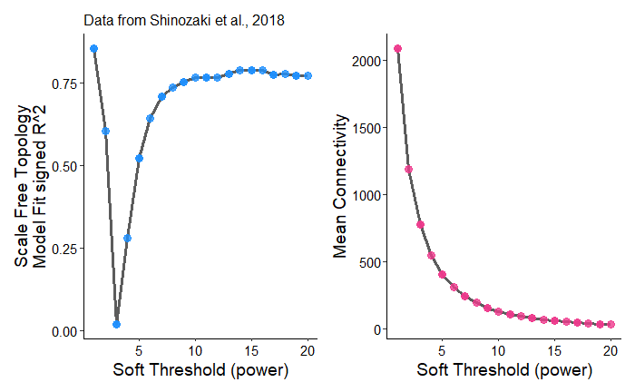

```r
ggsave("../Results/WGCNA_tomato_power.png", width = 6, height = 3, bg = "white")
```

Let’s go with power of 15, where the curves really flattern out.

# Detect modules

```r
picked_power <- 15
temp_cor <- cor
cor <- WGCNA::cor

tomato_WGCNA_network <- blockwiseModules(
  input_mat,

  power = picked_power,
  TOMType = "signed",
  networkType = "signed",

  pamRespectsDendro = F,
  minModuleSize = 30,

  mergeCutHeight = 0.25,

)

cor <- temp_cor
```

# Module membership

```r
module_df <- data.frame(
  gene.id = names(tomato_WGCNA_network$colors),
  module = tomato_WGCNA_network$colors
)

head(module_df)
```

|  | gene.id | module |
| --- | --- | --- |
| Solly.M82.00G000190.3 | Solly.M82.00G000190.3 | turquoise |
| Solly.M82.00G000220.1 | Solly.M82.00G000220.1 | grey |
| Solly.M82.00G000230.1 | Solly.M82.00G000230.1 | grey |
| Solly.M82.00G000270.1 | Solly.M82.00G000270.1 | turquoise |
| Solly.M82.00G000460.1 | Solly.M82.00G000460.1 | green |
| Solly.M82.00G000500.1 | Solly.M82.00G000500.1 | turquoise |

```r
module_df %>%
  group_by(module) %>%
  count()
```

| module | n |
| --- | --- |
| black | 203 |
| blue | 662 |
| brown | 577 |
| green | 273 |
| greenyellow | 81 |
| grey | 28 |
| magenta | 119 |
| pink | 187 |
| purple | 89 |
| red | 206 |

[output cut: 4 more lines]

We got 14 modules.

# Module-treatment correspondance

```r
Module_eigen <- moduleEigengenes(input_mat, tomato_WGCNA_network$colors)$eigengenes
```

## Heat map representation

### Reorder rows and columns

```r
Module_eigen_long <- Module_eigen %>%
  mutate(tag = row.names(.)) %>%
  pivot_longer(cols = !tag, names_to = "Module", values_to = "Eigen") %>%
  separate(tag, c("tissue", "dev_stage"), sep = "\\.") %>%
  mutate(order_x = case_when(
        str_detect(dev_stage, "5") ~ 1,
        str_detect(dev_stage, "10") ~ 2,
        str_detect(dev_stage, "20") ~ 3,
        str_detect(dev_stage, "30") ~ 4,
        str_detect(dev_stage, "MG") ~ 5,
        str_detect(dev_stage, "Br") ~ 6,
        str_detect(dev_stage, "Pk") ~ 7,
        str_detect(dev_stage, "LR") ~ 8,
        str_detect(dev_stage, "RR") ~ 9
  )) %>%
  mutate(stage = case_when(
    str_detect(dev_stage, "MG|Br|Pk") ~ str_sub(dev_stage, start = 1, end = 2),
    T ~ dev_stage
  )) %>%
  mutate(stage = factor(stage, levels = c(
   "5 DPA",
   "10 DPA",
   "20 DPA",
   "30 DPA",
   "MG",
   "Br",
   "Pk",
   "LR",
   "RR"
  ))) %>%
  mutate(dev_stage = reorder(dev_stage, order_x))


head(Module_eigen_long)
```

| tissue | dev_stage | Module | Eigen | order_x | stage |
| --- | --- | --- | --- | --- | --- |
| Placenta | 10 DPA | MEblack | 0.06880634 | 2 | 10 DPA |
| Placenta | 10 DPA | MEblue | -0.17102511 | 2 | 10 DPA |
| Placenta | 10 DPA | MEbrown | -0.04739418 | 2 | 10 DPA |
| Placenta | 10 DPA | MEgreen | 0.11503869 | 2 | 10 DPA |
| Placenta | 10 DPA | MEgreenyellow | -0.17523165 | 2 | 10 DPA |
| Placenta | 10 DPA | MEgrey | -0.03529231 | 2 | 10 DPA |

#### Module peak

```r
Module_eigen_long_peak <- Module_eigen_long %>%
  group_by(Module) %>%
  slice_max(order_by = Eigen, n = 1) %>%
  ungroup() %>%
  mutate(order_y = case_when(
        str_detect(dev_stage, "5") ~ 1,
        str_detect(dev_stage, "10") ~ 2,
        str_detect(dev_stage, "20") ~ 3,
        str_detect(dev_stage, "30") ~ 4,
        str_detect(dev_stage, "MG") ~ 5,
        str_detect(dev_stage, "Br") ~ 6,
        str_detect(dev_stage, "Pk") ~ 7,
        str_detect(dev_stage, "LR") ~ 8,
        str_detect(dev_stage, "RR") ~ 9
  )) %>%
  mutate(Module = reorder(Module, -order_y)) %>%
  mutate(peak_stage = dev_stage) %>%
  select(Module, order_y, peak_stage)


head(Module_eigen_long_peak)
```

| Module | order_y | peak_stage |
| --- | --- | --- |
| MEblack | 5 | MG-equatorial |
| MEblue | 7 | Pk-stylar |
| MEbrown | 7 | Pk-stylar |
| MEgreen | 1 | 5 DPA |
| MEgreenyellow | 6 | Br-stem |
| MEgrey | 7 | Pk-stylar |

```r
Module_eigen_long_reordered <- Module_eigen_long %>%
  full_join(Module_eigen_long_peak, by = "Module") %>%
  mutate(colors = str_remove(Module, "ME")) %>%
  mutate(Module = reorder(Module, -order_y)) %>%
   mutate(colors = reorder(colors, -order_y))
```

### Outliers

```r
summary(Module_eigen_long_reordered$Eigen)
```

```
    Min.  1st Qu.   Median     Mean  3rd Qu.     Max.
-0.25740 -0.07306 -0.02700  0.00000  0.07670  0.51476
```

```r
quantile(Module_eigen_long_reordered$Eigen, c(0.75,0.9, 0.95, 0.975, 0.99))
```

```
       75%        90%        95%      97.5%        99%
0.07670036 0.14146535 0.18424721 0.24869791 0.29347755
```

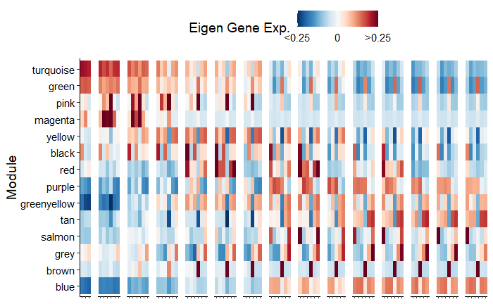

```r
tomato_WGCNA_heatmap <- Module_eigen_long_reordered %>%
  mutate(Eigen_clipped = case_when(
    Eigen > 0.25 ~ 0.25,
    Eigen < -0.25 ~ -0.25,
    T ~ Eigen
  )) %>%
  ggplot(aes(x = tissue, y = colors)) +
  facet_grid(.~ dev_stage, scales = "free", space = "free") +
  geom_tile(aes(fill = Eigen_clipped)) +
  scale_fill_gradientn(colors = rev(brewer.pal(11, "RdBu")),
                       limits = c(-0.25, 0.25),
                       breaks = c(-0.25, 0, 0.25),
                       labels = c("<0.25", "0" , ">0.25")) +
  labs(x = NULL,
       y = "Module",
       fill = "Eigen Gene Exp.") +
  theme_classic() +
  theme(
    text = element_text(size = 14),
    axis.text = element_text(color = "black"),
    axis.text.x = element_blank(),
    strip.text = element_blank(),
    legend.position = "top",
    panel.spacing = unit(0.5, "lines")
  )

tomato_WGCNA_heatmap
```

### Make color strip for heatmap

```r
module_df_colors <- Module_eigen_long_peak %>%
  mutate(colors = str_remove(Module, "ME"))

module_df_colors
```

| Module | order_y | peak_stage | colors |
| --- | --- | --- | --- |
| MEblack | 5 | MG-equatorial | black |
| MEblue | 7 | Pk-stylar | blue |
| MEbrown | 7 | Pk-stylar | brown |
| MEgreen | 1 | 5 DPA | green |
| MEgreenyellow | 6 | Br-stem | greenyellow |
| MEgrey | 7 | Pk-stylar | grey |
| MEmagenta | 3 | 20 DPA | magenta |
| MEpink | 3 | 20 DPA | pink |
| MEpurple | 6 | Br-stem | purple |
| MEred | 6 | Br-stem | red |

[output cut: 4 more lines]

```r
heat_map_color_strip_y <- module_df_colors %>%
  ggplot(aes(x = "", y = Module)) +
  geom_tile(aes(fill = colors)) +
  scale_fill_identity() +
  theme_void()
```

```r
heatmap_color_strip1 <- expand.grid(
  tissue = unique(Module_eigen_long$tissue),
  dev_stage = unique(Module_eigen_long$dev_stage),
  stringsAsFactors = F
) %>%
  mutate(dev_stage = as.character(dev_stage)) %>%
  filter(dev_stage != "Anthesis") %>%
  filter(str_detect(tissue, "epider|chyma|Vasc") == F) %>%
  filter((dev_stage == "5 DPA" &
           str_detect(tissue, "Locular tissue|Placenta|Seeds"))==F) %>%
  filter((str_detect(dev_stage, "styla") &
           str_detect(tissue, "Colum"))==F) %>%
  mutate(order_x = case_when(
        str_detect(dev_stage, "5") ~ 1,
        str_detect(dev_stage, "10") ~ 2,
        str_detect(dev_stage, "20") ~ 3,
        str_detect(dev_stage, "30") ~ 4,
        str_detect(dev_stage, "MG") ~ 5,
        str_detect(dev_stage, "Br") ~ 6,
        str_detect(dev_stage, "Pk") ~ 7,
        str_detect(dev_stage, "LR") ~ 8,
        str_detect(dev_stage, "RR") ~ 9
  )) %>%
  mutate(stage = case_when(
    str_detect(dev_stage, "MG|Br|Pk") ~ str_sub(dev_stage, start = 1, end = 2),
    T ~ dev_stage
  )) %>%
  mutate(stage = factor(stage, levels = c(
   "5 DPA",
   "10 DPA",
   "20 DPA",
   "30 DPA",
   "MG",
   "Br",
   "Pk",
   "LR",
   "RR"
  ))) %>%
  mutate(dev_stage = reorder(dev_stage, order_x)) %>%
  ggplot(aes(x = tissue, y = 1)) +
  facet_grid(.~ dev_stage, scales = "free", space = "free") +
  geom_tile(aes(fill = tissue)) +
  scale_fill_manual(values = brewer.pal(8, "Set2")) +
  guides(fill = guide_legend(nrow = 1)) +
  theme_void() +
  theme(
    legend.position = "bottom",
    strip.text = element_blank(),
    text = element_text(size = 14),
    panel.spacing = unit(0.5, "lines"),
    legend.key.height = unit(0.75, "lines")
  )


heatmap_color_strip2 <- expand.grid(
  tissue = unique(Module_eigen_long$tissue),
  dev_stage = unique(Module_eigen_long$dev_stage),
  stringsAsFactors = F
) %>%
  mutate(dev_stage = as.character(dev_stage)) %>%
  filter(dev_stage != "Anthesis") %>%
  filter(str_detect(tissue, "epider|chyma|Vasc") == F) %>%
  filter((dev_stage == "5 DPA" &
           str_detect(tissue, "Locular tissue|Placenta|Seeds"))==F) %>%
  filter((str_detect(dev_stage, "styla") &
           str_detect(tissue, "Colum"))==F) %>%
  mutate(order_x = case_when(
        str_detect(dev_stage, "5") ~ 1,
        str_detect(dev_stage, "10") ~ 2,
        str_detect(dev_stage, "20") ~ 3,
        str_detect(dev_stage, "30") ~ 4,
        str_detect(dev_stage, "MG") ~ 5,
        str_detect(dev_stage, "Br") ~ 6,
        str_detect(dev_stage, "Pk") ~ 7,
        str_detect(dev_stage, "LR") ~ 8,
        str_detect(dev_stage, "RR") ~ 9
  )) %>%
  mutate(stage = case_when(
    str_detect(dev_stage, "MG|Br|Pk") ~ str_sub(dev_stage, start = 1, end = 2),
    T ~ dev_stage
  )) %>%
  mutate(stage = factor(stage, levels = c(
   "5 DPA",
   "10 DPA",
   "20 DPA",
   "30 DPA",
   "MG",
   "Br",
   "Pk",
   "LR",
   "RR"
  ))) %>%
  mutate(dev_stage = reorder(dev_stage, order_x)) %>%
  ggplot(aes(x = tissue, y = 1)) +
  facet_grid(.~ dev_stage, scales = "free", space = "free") +
  geom_tile(aes(fill = stage)) +
  scale_fill_manual(values = viridis(9, option = "D")) +
  labs(fill = "stage") +
  guides(fill = guide_legend(nrow = 1)) +
  theme_void() +
  theme(
    legend.position = "bottom",
    strip.text = element_blank(),
    text = element_text(size = 14),
    panel.spacing = unit(0.5, "lines"),
    legend.key.height = unit(0.75, "lines")
  )

blank <- module_df_colors %>%
  ggplot(aes(x = "", y = Module)) +
  theme_void()
```

```r
wrap_plots(tomato_WGCNA_heatmap, heat_map_color_strip_y,
           heatmap_color_strip1, blank,
           heatmap_color_strip2, blank,
           nrow = 3, ncol = 2,
           heights = c(1, 0.05, 0.05),
           widths = c(1, 0.02), guides = "collect") &
  theme(
    legend.position = "bottom",
    legend.box = "vertical"
  )

ggsave("../Results/WGCNA_tomato_heatmap.svg", height = 4.8, width = 10, bg = "white")
```

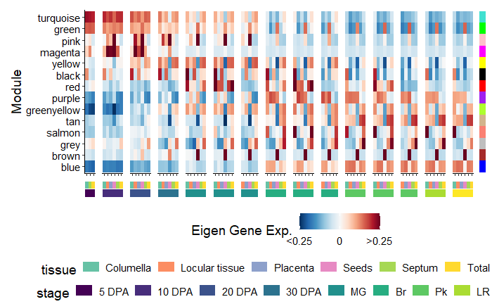

```r
ggsave("../Results/WGCNA_tomato_heatmap.png", height = 4.8, width = 10, bg = "white")
```

# Module QC

## Bait genes

We have two bait genes:

1. PG: Solly.M82.10G020850.1, involved in making the fruit softer
2. PSY1: Solly.M82.03G005440.5, involved in making the fruit red.

Let’s check which module(s) they are assigned to.

```r
module_df %>%
  filter(gene.id == "Solly.M82.10G020850.1" |
           gene.id == "Solly.M82.03G005440.5")
```

|  | gene.id | module |
| --- | --- | --- |
| Solly.M82.03G005440.5 | Solly.M82.03G005440.5 | blue |
| Solly.M82.10G020850.1 | Solly.M82.10G020850.1 | blue |

They are both in module “blue”. This is good to see, because we know they are involved in the same biological processes. I have no idea which one plum1 is looking at the heat map.

## Line graphs

```r
Exp_table_long_averaged_modules <- Exp_table_long_averaged %>%
  inner_join(module_df, by = c("gene_ID" = "gene.id")) %>%
  inner_join(module_df_colors %>%
               select(Module, colors), by = c("module"="colors")) %>%
  group_by(gene_ID) %>%
  mutate(z.score = (mean.logTPM - mean(mean.logTPM))/sd(mean.logTPM)) %>%
  ungroup()

head(Exp_table_long_averaged_modules)
```

| gene_ID | Sample Name | tissue | dev_stage | mean.logTPM | module | Module | z.score |
| --- | --- | --- | --- | --- | --- | --- | --- |
| Solly.M82.00G000190.3 | J10 | Placenta | 10 DPA | 1.1025570 | turquoise | MEturquoise | 1.2029826 |
| Solly.M82.00G000190.3 | J11 | Locular tissue | 10 DPA | 1.2318901 | turquoise | MEturquoise | 1.5012085 |
| Solly.M82.00G000190.3 | J12 | Seeds | 10 DPA | 1.7997030 | turquoise | MEturquoise | 2.8105125 |
| Solly.M82.00G000190.3 | J14 | Columella | 20 DPA | 0.9828509 | turquoise | MEturquoise | 0.9269558 |
| Solly.M82.00G000190.3 | J15 | Total pericarp | 20 DPA | 0.9965383 | turquoise | MEturquoise | 0.9585171 |
| Solly.M82.00G000190.3 | J16 | Septum | 20 DPA | 0.8554167 | turquoise | MEturquoise | 0.6331088 |

I computed z score here. Now I can graph a couple modules to check. We will do Module blue because that where our baits are. Let’s pick another one. I am picking module turquoise because according to peak expression, it peaks at the earliest stage of development.

Before we make the line graph, let’s also make an average of z scores for all the modules.

```r
tomato_WGCNA_modules_mean_z <- Exp_table_long_averaged_modules %>%
  group_by(dev_stage, tissue, module) %>%
  summarise(mean.z = mean(z.score)) %>%
  ungroup() %>%
  filter(is.na(mean.z)==F) %>%
  mutate(order_x = case_when(
        str_detect(dev_stage, "5") ~ 1,
        str_detect(dev_stage, "10") ~ 2,
        str_detect(dev_stage, "20") ~ 3,
        str_detect(dev_stage, "30") ~ 4,
        str_detect(dev_stage, "MG") ~ 5,
        str_detect(dev_stage, "Br") ~ 6,
        str_detect(dev_stage, "Pk") ~ 7,
        str_detect(dev_stage, "LR") ~ 8,
        str_detect(dev_stage, "RR") ~ 9
  )) %>%
  mutate(dev_stage = reorder(dev_stage, order_x))
head(tomato_WGCNA_modules_mean_z)
```

| dev_stage | tissue | module | mean.z | order_x |
| --- | --- | --- | --- | --- |
| 10 DPA | Columella | black | 0.9201967 | 2 |
| 10 DPA | Columella | blue | -1.2307580 | 2 |
| 10 DPA | Columella | brown | -0.4185051 | 2 |
| 10 DPA | Columella | green | 0.9059841 | 2 |
| 10 DPA | Columella | greenyellow | -1.2117837 | 2 |
| 10 DPA | Columella | grey | -0.2984237 | 2 |

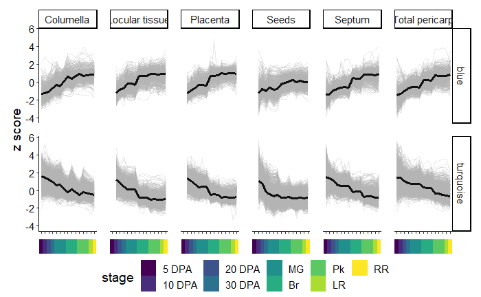

# Heatmap for module z score

```r
tomato_WGCNA_modules_mean_z_reordered <- tomato_WGCNA_modules_mean_z %>%
  inner_join(Module_eigen_long_peak %>%
               mutate(module = str_remove(Module, "ME")),
             by = "module") %>%
  mutate(module = reorder(module, -order_y))

head(tomato_WGCNA_modules_mean_z_reordered)
```

| dev_stage | tissue | module | mean.z | order_x | Module | order_y | peak_stage |
| --- | --- | --- | --- | --- | --- | --- | --- |
| 10 DPA | Columella | black | 0.9201967 | 2 | MEblack | 5 | MG-equatorial |
| 10 DPA | Columella | blue | -1.2307580 | 2 | MEblue | 7 | Pk-stylar |
| 10 DPA | Columella | brown | -0.4185051 | 2 | MEbrown | 7 | Pk-stylar |
| 10 DPA | Columella | green | 0.9059841 | 2 | MEgreen | 1 | 5 DPA |
| 10 DPA | Columella | greenyellow | -1.2117837 | 2 | MEgreenyellow | 6 | Br-stem |
| 10 DPA | Columella | grey | -0.2984237 | 2 | MEgrey | 7 | Pk-stylar |

```r
tomato_WGCNA_modules_mean_z_reordered$mean.z %>% summary()
```

```
   Min. 1st Qu.  Median    Mean 3rd Qu.    Max.
-1.9264 -0.4970 -0.1840  0.0000  0.5048  4.2597
```

```r
quantile(tomato_WGCNA_modules_mean_z_reordered$mean.z, c(0.025, 0.975))
```

```
     2.5%     97.5%
-1.288275  1.873367
```

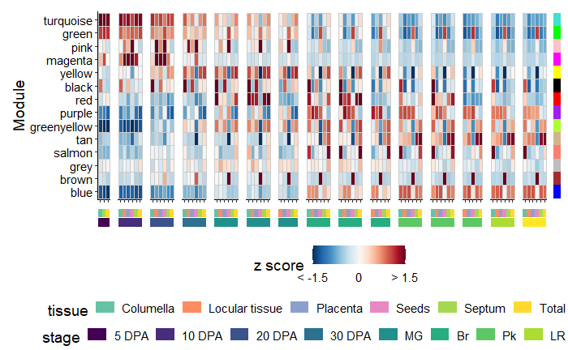

# Cross-workflow comparison

## Correspondance

### Wide of WGCNA

```r
tomato_WGCNA_modules_mean_z_reordered_wide <- tomato_WGCNA_modules_mean_z_reordered %>%
  select(dev_stage, tissue, module, mean.z) %>%
  mutate(tag = paste(tissue, dev_stage, sep = ";")) %>%
  select(-tissue, -dev_stage) %>%
  pivot_wider(names_from = module, values_from = mean.z) %>%
  as.data.frame()

row.names(tomato_WGCNA_modules_mean_z_reordered_wide) <- tomato_WGCNA_modules_mean_z_reordered_wide$tag
head(tomato_WGCNA_modules_mean_z_reordered_wide)
```

|  | tag | black | blue | brown | green | greenyellow | grey | magenta | pink | purple | red | salmon | tan | turquoise | yellow |
| --- | --- | --- | --- | --- | --- | --- | --- | --- | --- | --- | --- | --- | --- | --- | --- |
| Columella;10 DPA | Columella;10 DPA | 0.9201967 | -1.230758 | -0.4185051 | 0.9059841 | -1.211784 | -0.29842374 | 0.68570455 | -0.02736847 | -1.0097611 | -0.3762265 | -0.5860900 | -0.6876623 | 1.398468 | 0.089686276 |
| Locular tissue;10 DPA | Locular tissue;10 DPA | -0.3239310 | -1.175630 | -0.3261513 | 0.7068418 | -1.405709 | 0.01321448 | 2.61429111 | 0.82100250 | -0.6935126 | -0.3473572 | -0.3091499 | -0.6429794 | 1.188953 | -0.123179297 |
| Placenta;10 DPA | Placenta;10 DPA | 0.4803197 | -1.226493 | -0.3669145 | 0.8168041 | -1.312782 | -0.14152742 | 1.97387719 | 0.50956133 | -0.8663327 | -0.7415901 | -0.6932093 | -0.7167102 | 1.338664 | 0.019865524 |
| Seeds;10 DPA | Seeds;10 DPA | -0.3371918 | -1.204267 | -0.1036194 | 0.9256083 | -1.926437 | 0.06334132 | 4.21882904 | 1.82713238 | -0.4002448 | -0.3406513 | -0.4764333 | -1.1628507 | 1.043997 | -0.798821581 |
| Septum;10 DPA | Septum;10 DPA | -0.1440181 | -1.324950 | -0.4831181 | 0.8646754 | -1.394177 | -0.30260845 | 1.20218010 | 0.04371777 | -1.1411500 | -0.5923627 | -0.7043380 | -0.5238995 | 1.365674 | 0.000523069 |
| Total pericarp;10 DPA | Total pericarp;10 DPA | -0.2577190 | -1.307221 | -0.5320898 | 1.0350575 | -1.286769 | 0.25816509 | -0.01235036 | -0.41677811 | -1.2437139 | -0.1516938 | -0.5685425 | -0.2420399 | 1.399006 | 0.013610838 |

### Wide of Simple Tidy GeneCoEx

```r
modules_mean_z_reorded_wide <- modules_mean_z_reorded %>%
  select(dev_stage, tissue, module, mean.z) %>%
  mutate(tag = paste(tissue, dev_stage, sep = ";")) %>%
  select(-tissue, -dev_stage) %>%
  pivot_wider(names_from = module, values_from = mean.z) %>%
  as.data.frame()

row.names(modules_mean_z_reorded_wide) <- modules_mean_z_reorded_wide$tag
head(modules_mean_z_reorded_wide)
```

|  | tag | 1 | 2 | 3 | 4 | 5 | 7 | 8 | 9 | 14 | 16 | 19 | 22 | 33 | 37 | 67 | 114 |
| --- | --- | --- | --- | --- | --- | --- | --- | --- | --- | --- | --- | --- | --- | --- | --- | --- | --- |
| Columella;10 DPA | Columella;10 DPA | 1.896110 | 1.41859240 | 0.3950909 | -0.28179792 | -1.133491 | 0.9887064 | 0.3537383 | -0.2781120 | 1.0881020 | 0.517489129 | 1.6613397 | 1.0659194 | 1.2033742 | 1.3729978 | 0.9339507 | 2.0278521 |
| Locular tissue;10 DPA | Locular tissue;10 DPA | 1.879599 | 0.11715549 | 0.4948352 | -0.22395658 | -1.084556 | 0.6262549 | 0.1432054 | -0.1686676 | 1.1694098 | 1.918510740 | 1.3806836 | 1.5937464 | 0.8003701 | 0.8754258 | 1.3259245 | 1.0162663 |
| Placenta;10 DPA | Placenta;10 DPA | 1.902788 | 0.97990056 | 0.4745874 | -0.59767563 | -1.136004 | 0.8302132 | 0.2884602 | -0.2072096 | 1.1562840 | 1.450311592 | 1.8263728 | 1.3130604 | 0.9229409 | 1.2123085 | 1.0728928 | 1.7505645 |
| Seeds;10 DPA | Seeds;10 DPA | 2.137981 | 0.09036625 | 0.4189892 | -0.19840673 | -1.171469 | 0.6464504 | -0.3766641 | 0.1243201 | 0.4133173 | 3.288914106 | 0.2957777 | 0.9502537 | 0.9949636 | 1.5873334 | -0.3227643 | 0.9536578 |
| Septum;10 DPA | Septum;10 DPA | 1.947724 | 0.35626693 | 1.1160115 | -0.47566369 | -1.226603 | 0.8035823 | 0.2456424 | -0.3220098 | 1.4001175 | 0.830985684 | 1.6707818 | 1.0551810 | 1.2715968 | 1.2268091 | 1.1799838 | 1.1868782 |
| Total pericarp;10 DPA | Total pericarp;10 DPA | 1.938645 | 0.19392294 | 1.9755748 | -0.09782268 | -1.189501 | 0.8534054 | 0.2338809 | -0.3499907 | 1.4801325 | -0.004025622 | 1.1681861 | 0.6878343 | 1.3847155 | 1.4094702 | 1.1352073 | 0.9651678 |

```r
modules_mean_z_reorded_wide$tag == tomato_WGCNA_modules_mean_z_reordered_wide$tag
```

```
 [1] TRUE TRUE TRUE TRUE TRUE TRUE TRUE TRUE TRUE TRUE TRUE TRUE TRUE TRUE TRUE TRUE TRUE TRUE TRUE TRUE TRUE TRUE TRUE TRUE TRUE TRUE TRUE TRUE
[29] TRUE TRUE TRUE TRUE TRUE TRUE TRUE TRUE TRUE TRUE TRUE TRUE TRUE TRUE TRUE TRUE TRUE TRUE TRUE TRUE TRUE TRUE TRUE TRUE TRUE TRUE TRUE TRUE
[57] TRUE TRUE TRUE TRUE TRUE TRUE TRUE TRUE TRUE TRUE TRUE TRUE TRUE TRUE TRUE TRUE TRUE TRUE TRUE TRUE TRUE TRUE TRUE TRUE TRUE TRUE TRUE TRUE
```

### Find corresponding modules

```r
head(Corresonding_modules)
```

```
          black       blue      brown       green greenyellow       grey    magenta        pink      purple         red       salmon        tan
[1,]  0.1962344 -0.8317043 -0.1061974  0.65504960  -0.6162145 -0.0302880  0.6940771  0.34818903 -0.62129605 -0.15909867 -0.234943375 -0.4230059
[2,]  0.9506256 -0.4470094 -0.3430225  0.32475986   0.2039414  0.1232475  0.1958900  0.04856310 -0.52946048  0.33880569  0.280638490 -0.1332023
[3,]  0.1595446 -0.7130015 -0.1791354  0.58934508  -0.1298803  0.2607050  0.2814002  0.04965133 -0.84780991  0.02319714  0.001322195 -0.1185312
[4,]  0.5118003  0.1477667 -0.2622995 -0.07504452   0.5032844  0.4459091 -0.1887067 -0.27238401 -0.07853152  0.98648158  0.644711688  0.2296913
[5,] -0.1062382  0.9943753 -0.2208443 -0.86547992   0.6382538  0.0271285 -0.5789993 -0.58118934  0.61655973  0.24753677  0.363497224  0.7268716
[6,]  0.4084826 -0.8913198  0.2345525  0.90271366  -0.2812050  0.1451273  0.4246088  0.47121103 -0.63286223  0.03963621 -0.007478645 -0.6429335
      turquoise      yellow
[1,]  0.8555939  0.11461473
[2,]  0.7029069  0.66136831
[3,]  0.7899221  0.47890260
[4,]  0.1180713  0.45092320
[5,] -0.8034288 -0.07387456
[6,]  0.8096249  0.34253238
```

```r
Corresonding_modules_long <- Corresonding_modules %>%
  as.data.frame() %>%
  cbind(SimpleTidy_GeneCoEx = colnames(modules_mean_z_reorded_wide)[-1]) %>%
  pivot_longer(cols = ! SimpleTidy_GeneCoEx, names_to = "WGCNA", values_to = "r") %>%
  inner_join(module_peak_exp %>%
               mutate(module = as.character(module)) %>%
               select(dev_stage, tissue, module, order_y, peak_exp),
             by = c("SimpleTidy_GeneCoEx" = "module")) %>%
  rename(order_simple = order_y) %>%
  inner_join(
    tomato_WGCNA_modules_mean_z_reordered %>%
  group_by(module, order_y, peak_stage) %>%
  count() %>%
    select(-n),
  by = c("WGCNA" = "module")
  ) %>%
  rename(order_WGCNA = order_y) %>%
  mutate(SimpleTidy_GeneCoEx = reorder(SimpleTidy_GeneCoEx, -order_simple)) %>%
  mutate(WGCNA = reorder(WGCNA,  order_WGCNA))


head(Corresonding_modules_long)
```

| SimpleTidy_GeneCoEx | WGCNA | r | dev_stage | tissue | order_simple | peak_exp | order_WGCNA | peak_stage |
| --- | --- | --- | --- | --- | --- | --- | --- | --- |
| 1 | black | 0.1962344 | 5 DPA | Septum | 1 | 5 DPA | 5 | MG-equatorial |
| 1 | blue | -0.8317043 | 5 DPA | Septum | 1 | 5 DPA | 7 | Pk-stylar |
| 1 | brown | -0.1061974 | 5 DPA | Septum | 1 | 5 DPA | 7 | Pk-stylar |
| 1 | green | 0.6550496 | 5 DPA | Septum | 1 | 5 DPA | 1 | 5 DPA |
| 1 | greenyellow | -0.6162145 | 5 DPA | Septum | 1 | 5 DPA | 6 | Br-stem |
| 1 | grey | -0.0302880 | 5 DPA | Septum | 1 | 5 DPA | 7 | Pk-stylar |

```r
Corresonding_modules_long %>%
  filter(WGCNA == "blue") %>%
  filter(SimpleTidy_GeneCoEx == "5")
```

| SimpleTidy_GeneCoEx | WGCNA | r | dev_stage | tissue | order_simple | peak_exp | order_WGCNA | peak_stage |
| --- | --- | --- | --- | --- | --- | --- | --- | --- |
| 5 | blue | 0.9943753 | Pk-stylar | Placenta | 7 | Pk-stylar | 7 | Pk-stylar |

```r
Corresonding_modules_long %>%
  filter(WGCNA == "brown") %>%
  filter(SimpleTidy_GeneCoEx == "9")
```

| SimpleTidy_GeneCoEx | WGCNA | r | dev_stage | tissue | order_simple | peak_exp | order_WGCNA | peak_stage |
| --- | --- | --- | --- | --- | --- | --- | --- | --- |
| 9 | brown | 0.9926307 | Pk-stylar | Seeds | 7 | Pk-stylar | 7 | Pk-stylar |

```r
Corresonding_modules_heatmap <- Corresonding_modules_long %>%
  ggplot(aes(x = SimpleTidy_GeneCoEx, y = WGCNA)) +
  geom_tile(aes(fill = r)) +
  scale_fill_gradientn(colours = rev(brewer.pal(11, "RdBu")),
                       limits = c(-1, 1),
                       breaks = c(-0.9, 0, 0.9))+
  labs(x = "Simple Tidy GeneCoEx Modules",
       y = "WGCNA Modules") +
  theme_minimal() +
  theme(
    legend.position = "top",
    text = element_text(size = 14),
    axis.text = element_text(color = "black"),
    #axis.text.y = element_blank(),
    legend.key.width = unit(1.2, "lines"),
    panel.grid = element_blank()
  )


Corresonding_modules_heatmap

ggsave("../Results/Tomato_correspondance.svg", height = 5, width = 7)
```

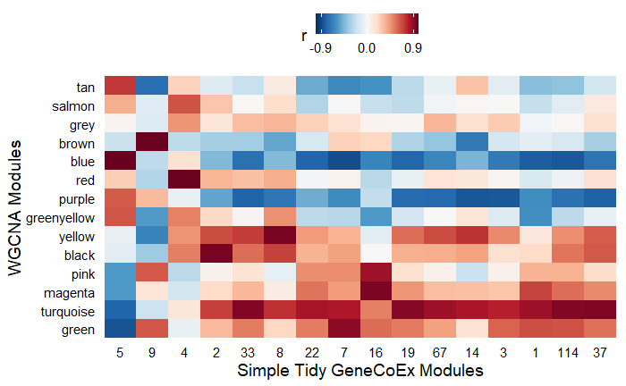

```r
ggsave("../Results/Tomato_correspondance.png", height = 5, width = 7)
```

## Squared error loss

### Simple Tidy Gene CoEx

```r
Tomato_tidy_msqs <- Exp_table_long_averaged_z_high_var_modules %>%
  group_by(module, tissue, dev_stage) %>%
  mutate(mean = mean(z.score)) %>%
  mutate(squares = (z.score - mean)^2) %>%
  ungroup() %>%
  group_by(module) %>%
  summarise(
    ssq = sum(squares)
  ) %>%
  ungroup() %>%
  inner_join(
    my_network_modules %>%
      group_by(module) %>%
      count(),
    by = "module"
  ) %>%
  mutate(msq = ssq/n)

Tomato_tidy_msqs
```

| module | ssq | n | msq |
| --- | --- | --- | --- |
| 1 | 9694.1954 | 522 | 18.57126 |
| 2 | 12035.3320 | 393 | 30.62425 |
| 3 | 5129.2109 | 159 | 32.25919 |
| 4 | 9317.3444 | 264 | 35.29297 |
| 5 | 40958.4145 | 954 | 42.93335 |
| 7 | 8399.0998 | 305 | 27.53803 |
| 8 | 12214.6655 | 465 | 26.26810 |
| 9 | 18960.4210 | 712 | 26.62980 |
| 14 | 5762.7051 | 247 | 23.33079 |
| 16 | 6124.6301 | 236 | 25.95182 |

[output cut: 6 more lines]

### WGCNA

```r
Tomato_WGCNA_msq <-Exp_table_long_averaged_modules %>%
 # filter(module != "grey") %>%
  group_by(module, tissue, dev_stage) %>%
  mutate(mean = mean(z.score)) %>%
  mutate(squares = (z.score - mean)^2) %>%
  ungroup() %>%
  group_by(module) %>%
  summarise(
    ssq = sum(squares)
  ) %>%
  ungroup() %>%
  inner_join(
    module_df %>%
      group_by(module) %>%
      count(),
    by = "module"
  ) %>%
  mutate(msq = ssq/n) %>%
  filter(is.na(msq) == F)

head(Tomato_WGCNA_msq)
```

| module | ssq | n | msq |
| --- | --- | --- | --- |
| black | 5356.795 | 203 | 26.38815 |
| blue | 21527.778 | 662 | 32.51930 |
| brown | 13208.768 | 577 | 22.89215 |
| green | 8027.226 | 273 | 29.40376 |
| greenyellow | 2109.175 | 81 | 26.03920 |
| grey | 2139.997 | 28 | 76.42846 |

### Comparison

```r
lost_function_comparisons <- rbind(
  Tomato_tidy_msqs %>%
    select(msq, n) %>%
    mutate(method = "Simple Tidy"),
  Tomato_WGCNA_msq %>%
    select(msq, n) %>%
    mutate(method = "WGCNA")
)

lost_function_comparisons_s <-lost_function_comparisons %>%
  group_by(method) %>%
  summarise(
    mean = mean(msq),
    median = median(msq),
    sd = sd(msq),
    NN = n()
  )

lost_function_comparisons_s
```

| method | mean | median | sd | NN |
| --- | --- | --- | --- | --- |
| Simple Tidy | 24.97888 | 26.10996 | 8.000532 | 16 |
| WGCNA | 30.35709 | 28.03254 | 13.982202 | 14 |

```r
wilcox.test(lost_function_comparisons$msq ~ lost_function_comparisons$method)
```

```
    Wilcoxon rank sum exact test

data:  lost_function_comparisons$msq by lost_function_comparisons$method
W = 83, p-value = 0.24
alternative hypothesis: true location shift is not equal to 0
```

```r
cor.test(lost_function_comparisons$msq, lost_function_comparisons$n)
```

```
    Pearson's product-moment correlation

data:  lost_function_comparisons$msq and lost_function_comparisons$n
t = 0.73269, df = 28, p-value = 0.4698
alternative hypothesis: true correlation is not equal to 0
95 percent confidence interval:
 -0.2347094  0.4740046
sample estimates:
      cor
0.1371577
```

```r
median_separation <- lost_function_comparisons %>%
  ggplot(aes(x = method, y = msq)) +
  # geom_boxplot(width = 0.3) +
  ggbeeswarm::geom_quasirandom(aes(fill = method), size = 3,
                                shape = 21, alpha = 0.8, color = "white") +
  scale_fill_manual(values = c("tomato1", "grey30")) +
  labs(x = "method",
       y = "loss function\n(mean sum of squares)",
       title = "Data from Shinozaki et al., 2018",
       caption = paste0(
         "median1 = ", signif(lost_function_comparisons_s[1, 3], 3), "; ",
         "median2 = ", signif(lost_function_comparisons_s[2, 3], 3), "\n",
         "P = ",
         signif(
           wilcox.test(lost_function_comparisons$msq ~ lost_function_comparisons$method)$p.value,
           2),
         "\n(Wilcoxon Rank Sum Test)"
       )) +
  theme_classic()+
  theme(
    legend.position = "none",
    text = element_text(size = 14),
    axis.text = element_text(color = "black"),
    plot.title = element_text(size = 12),
    plot.caption = element_text(size = 12, hjust = 0)
  )

msq_n_scatter <- lost_function_comparisons %>%
  ggplot(aes(x = n,  y = msq)) +
  geom_point(aes(fill = method), size = 3,
                                shape = 21, alpha = 0.8, color = "white") +
  scale_fill_manual(values = c("tomato1", "grey30")) +
  labs(
    y = "loss function\n(mean sum of squares)",
    x = "Num. genes in module",
    caption = paste0(
      "r = ", signif(
        cor.test(lost_function_comparisons$msq, lost_function_comparisons$n)$estimate, 3
      )
    )
  ) +
  theme_classic() +
  theme(
    legend.position = c(0.8, 0.2),
    text = element_text(size = 14),
    axis.text = element_text(color = "black"),
    plot.title = element_text(size = 12),
    plot.caption = element_text(size = 12, hjust = 0)
  )

wrap_plots(median_separation,
           msq_n_scatter,
           nrow = 1)

ggsave("../Results/Tomato_benchmarking_results.svg", height = 4, width = 7, bg = "white")
```

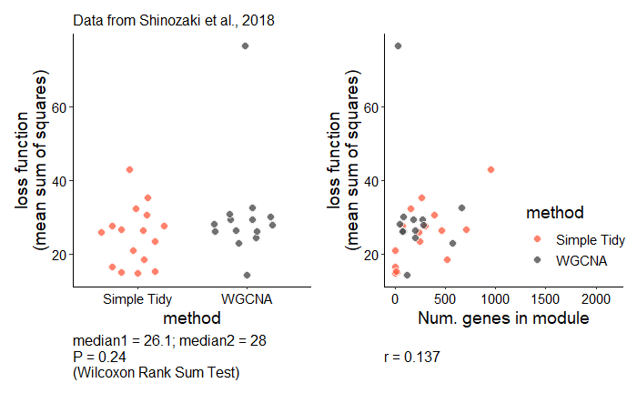

```r
ggsave("../Results/Tomato_benchmarking_results.png", height = 4, width = 7, bg = "white")
```

## Controlling for module size

```r
model_tomato <- lm(msq ~ n + method, data = lost_function_comparisons)
anova(model_tomato)
```

```
Analysis of Variance Table

Response: msq
          Df Sum Sq Mean Sq F value Pr(>F)
n          1   69.9  69.937  0.5468 0.4660
method     1  194.0 194.036  1.5169 0.2287
Residuals 27 3453.7 127.913
```

# Membership comparison

```r
module_df
```

|  | gene.id | module |
| --- | --- | --- |
| Solly.M82.00G000190.3 | Solly.M82.00G000190.3 | turquoise |
| Solly.M82.00G000220.1 | Solly.M82.00G000220.1 | grey |
| Solly.M82.00G000230.1 | Solly.M82.00G000230.1 | grey |
| Solly.M82.00G000270.1 | Solly.M82.00G000270.1 | turquoise |
| Solly.M82.00G000460.1 | Solly.M82.00G000460.1 | green |
| Solly.M82.00G000500.1 | Solly.M82.00G000500.1 | turquoise |
| Solly.M82.00G000590.1 | Solly.M82.00G000590.1 | red |
| Solly.M82.00G001200.1 | Solly.M82.00G001200.1 | black |
| Solly.M82.00G001420.1 | Solly.M82.00G001420.1 | greenyellow |
| Solly.M82.01G000020.2 | Solly.M82.01G000020.2 | turquoise |

[output cut: 990 more lines]

```r
my_network_modules
```

| gene_ID | module | functional_annotation |
| --- | --- | --- |
| Solly.M82.00G000190.3 | 1 | vacuolar iron transporter (VIT) family protein |
| Solly.M82.00G000220.1 | 2 | response to low sulfur |
| Solly.M82.00G000230.1 | 2 | response to low sulfur |
| Solly.M82.00G000270.1 | 3 | Glucose-1-phosphate adenylyltransferase family protein |
| Solly.M82.00G000460.1 | 1 | hypothetical protein |
| Solly.M82.00G000500.1 | 2 | Bifunctional inhibitor/lipid-transfer protein/seed storage 2S albumin superfamily protein |
| Solly.M82.00G000590.1 | 4 | DDE superfamily endonuclease domain containing protein |
| Solly.M82.00G001200.1 | 2 | Eukaryotic aspartyl protease family protein |
| Solly.M82.00G001420.1 | 5 | hypothetical protein |
| Solly.M82.01G000020.2 | 2 | glutamate decarboxylase |

[output cut: 990 more lines]

```r
find_overlap <- function(SimpleTidy_module, WGCNA_module){
   x = my_network_modules %>%
     filter(module == SimpleTidy_module)

   y = module_df %>%
     rename(gene_ID = gene.id) %>%
     filter(module == WGCNA_module)

   intersect(x$gene_ID, y$gene_ID) %>%
     length()
}

find_overlap(
  SimpleTidy_module = "5",
  WGCNA_module = "blue"
)
```

```
[1] 654
```

```r
module_combinations <- expand.grid(
   SimpleTidy_module = unique(my_network_modules$module),
   WGCNA_module = unique(module_df$module)
)

membership_overlap <- mapply(FUN = find_overlap,
       module_combinations$SimpleTidy_module,
       module_combinations$WGCNA_module) %>%
  as.data.frame() %>%
  rename(overlap = ".") %>%
  cbind(module_combinations)

head(membership_overlap)
```

|  | overlap | SimpleTidy_module | WGCNA_module |
| --- | --- | --- | --- |
| 1 | 488 | 1 | turquoise |
| 2 | 190 | 2 | turquoise |
| 3 | 135 | 3 | turquoise |
| 4 | 21 | 4 | turquoise |
| 5 | 0 | 5 | turquoise |
| 6 | 150 | 7 | turquoise |

```r
membership_overlap_annotated <- membership_overlap %>%
  mutate(Module = paste0("ME", WGCNA_module)) %>%
  inner_join(module_df_colors, by = "Module") %>%
  inner_join(module_peak_exp, by = c("SimpleTidy_module" = "module"))

head(membership_overlap_annotated)
```

|  | overlap | SimpleTidy_module | WGCNA_module | Module | order_y.x | peak_stage | colors | dev_stage | tissue | Sample Name | mean.z | order_y.y | peak_exp |
| --- | --- | --- | --- | --- | --- | --- | --- | --- | --- | --- | --- | --- | --- |
| 1 | 488 | 1 | turquoise | MEturquoise | 1 | 5 DPA | turquoise | 5 DPA | Septum | J5 | 2.6997700 | 1 | 5 DPA |
| 2 | 190 | 2 | turquoise | MEturquoise | 1 | 5 DPA | turquoise | MG-equatorial | Columella | J34 | 1.9919200 | 5 | MG-equatorial |
| 3 | 135 | 3 | turquoise | MEturquoise | 1 | 5 DPA | turquoise | 10 DPA | Total pericarp | J8 | 1.9755748 | 2 | 10 DPA |
| 4 | 21 | 4 | turquoise | MEturquoise | 1 | 5 DPA | turquoise | Br-stem | Columella | J46 | 2.3404798 | 6 | Br-stem |
| 5 | 0 | 5 | turquoise | MEturquoise | 1 | 5 DPA | turquoise | Pk-stylar | Placenta | J78 | 0.8918667 | 7 | Pk-stylar |
| 6 | 150 | 7 | turquoise | MEturquoise | 1 | 5 DPA | turquoise | 30 DPA | Columella | J21 | 1.0834452 | 4 | 30 DPA |

## Alluvial plot

```r
membership_overlap_annotated %>%
  mutate(peak_exp = as.character(peak_exp)) %>%
  mutate(stage = case_when(
    str_detect(peak_exp, "MG|Br|Pk") ~ str_sub(peak_exp, start = 1, end = 2),
    T ~ peak_exp
  )) %>%
  mutate(stage = factor(stage, levels = c(
   "5 DPA",
   "10 DPA",
   "20 DPA",
   "30 DPA",
   "MG",
   "Br",
   "Pk",
   "LR",
   "RR"
  ))) %>%
  ggplot(aes(y = overlap,
           axis1 = as.factor(SimpleTidy_module),
           axis2 = colors)) +
  geom_alluvium(aes(fill = stage), alpha = 0.8) +
  geom_stratum(fill = "grey70", color = "grey30", width = 0.05) +
  scale_x_discrete(labels = c("Simple Tidy", "WGCNA"),
                   limits = c("Simple Tidy", "WGCNA"),
                   expand = c(0.01, 0.01)) +
  scale_fill_manual(values = viridis(9, option = "D")[c(-4, -8)]) +
  labs(x = "method",
       y = "number of genes",
       fill = "peak\nexpression") +
  theme_minimal() +
  theme(
    legend.position = "bottom",
    text = element_text(size = 14),
    axis.text = element_text(color = "black"),
    panel.grid = element_blank()
  ) +
  coord_flip()

ggsave("../Results/WGCNA_tidy_memebership.svg", height = 3, width = 8, bg = "white")
```

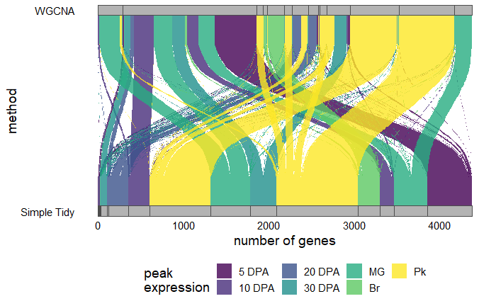

```r
ggsave("../Results/WGCNA_tidy_memebership.png", height = 3, width = 8, bg = "white")
```